# MachineProj_BoostingVersion

#Importing data and libraries

```r
library(randomForest)
library(dplyr)
houses.test = read.csv("C:\\Storage\\Notes\\Datasets\\house-prices-advanced-regression-techniques\\test.csv", stringsAsFactors = FALSE) %>% mutate(is.train=0)
houses.train = read.csv("C:\\Storage\\Notes\\Datasets\\house-prices-advanced-regression-techniques\\train.csv", stringsAsFactors = FALSE) %>% mutate(is.train=1)
```

#Removing Respose vector and combining sets for feature engineering

```r
SP<-houses.train$SalePrice
houses.train$SalePrice<-NULL
Houses.Full<-rbind(houses.train, houses.test)
```

#seed here while I’m making sure this code works for reproducing results will remove later

```r
set.seed(143)
```

# Many NA values that are actually levels

#For garage variables na in finish indicates no garage so no values expected for the other garage variables either #For columns with na’s that total less than 2% of the data(which is pretty much all of them) median and mean values were used instead

```r
Houses.Full$Alley[is.na(Houses.Full$Alley)] <- "invalid"
Houses.Full$BsmtQual[is.na(Houses.Full$BsmtQual)] <- "invalid"
Houses.Full$BsmtCond[is.na(Houses.Full$BsmtCond)] <- "invalid"
Houses.Full$BsmtExposure[is.na(Houses.Full$BsmtExposure)] <- "invalid"
Houses.Full$BsmtFinType1[is.na(Houses.Full$BsmtFinType1)] <- "invalid"
Houses.Full$BsmtFinType2[is.na(Houses.Full$BsmtFinType2)] <- "invalid"
Houses.Full$FireplaceQu[is.na(Houses.Full$FireplaceQu)] <- "invalid"
Houses.Full$GarageType[is.na(Houses.Full$GarageFinish)] <- "invalid"
Houses.Full$GarageYrBlt[is.na(Houses.Full$GarageFinish)] <- "invalid"
Houses.Full$GarageFinish[is.na(Houses.Full$GarageFinish)] <- "invalid"
Houses.Full$GarageCond[is.na(Houses.Full$GarageCond)] <- "invalid"
Houses.Full$GarageQual[is.na(Houses.Full$GarageQual)]<-"invalid"
Houses.Full$PoolQC[is.na(Houses.Full$PoolQC)] <- "invalid"
Houses.Full$Fence[is.na(Houses.Full$Fence)] <- "invalid"
Houses.Full$MiscFeature[is.na(Houses.Full$MiscFeature)] <- "invalid"
Houses.Full$MSZoning[is.na(Houses.Full$MSZoning)] <- "RL"
Houses.Full$Utilities[is.na(Houses.Full$Utilities)] <- "AllPub"
Houses.Full$Exterior1st[is.na(Houses.Full$Exterior1st)] <- "VinylSd"
Houses.Full$Exterior2nd[is.na(Houses.Full$Exterior2nd)] <- "VinylSd"
Houses.Full$MasVnrType[is.na(Houses.Full$MasVnrType)] <- "None"
Houses.Full$MasVnrArea[is.na(Houses.Full$MasVnrArea)] <- 0.0
Houses.Full$BsmtFinSF1 <- na.roughfix(Houses.Full$BsmtFinSF1)
Houses.Full$BsmtFinSF2 <- na.roughfix(Houses.Full$BsmtFinSF2)
Houses.Full$BsmtUnfSF <- na.roughfix(Houses.Full$BsmtUnfSF)
Houses.Full$TotalBsmtSF <- na.roughfix(Houses.Full$TotalBsmtSF)
Houses.Full$Electrical[is.na(Houses.Full$Electrical)]<-"SBrkr"
Houses.Full$BsmtFullBath[is.na(Houses.Full$BsmtFullBath)] <- 0.0
Houses.Full$BsmtHalfBath[is.na(Houses.Full$BsmtHalfBath)] <- 0.0
Houses.Full$KitchenQual[is.na(Houses.Full$KitchenQual)] <- "TA"
Houses.Full$Functional[is.na(Houses.Full$Functional)] <- "Typ"
Houses.Full$GarageCars[is.na(Houses.Full$GarageCars)] <- 2.0
Houses.Full$GarageArea <- na.roughfix(Houses.Full$GarageArea)
Houses.Full$SaleType[is.na(Houses.Full$SaleType)] <- "WD"
```

```r
colSums(is.na(Houses.Full))
```

```
           Id    MSSubClass      MSZoning   LotFrontage       LotArea        Street         Alley
            0             0             0           486             0             0             0
     LotShape   LandContour     Utilities     LotConfig     LandSlope  Neighborhood    Condition1
            0             0             0             0             0             0             0
   Condition2      BldgType    HouseStyle   OverallQual   OverallCond     YearBuilt  YearRemodAdd
            0             0             0             0             0             0             0
    RoofStyle      RoofMatl   Exterior1st   Exterior2nd    MasVnrType    MasVnrArea     ExterQual
            0             0             0             0             0             0             0
    ExterCond    Foundation      BsmtQual      BsmtCond  BsmtExposure  BsmtFinType1    BsmtFinSF1
            0             0             0             0             0             0             0
 BsmtFinType2    BsmtFinSF2     BsmtUnfSF   TotalBsmtSF       Heating     HeatingQC    CentralAir
            0             0             0             0             0             0             0
   Electrical     X1stFlrSF     X2ndFlrSF  LowQualFinSF     GrLivArea  BsmtFullBath  BsmtHalfBath
            0             0             0             0             0             0             0
     FullBath      HalfBath  BedroomAbvGr  KitchenAbvGr   KitchenQual  TotRmsAbvGrd    Functional
            0             0             0             0             0             0             0
   Fireplaces   FireplaceQu    GarageType   GarageYrBlt  GarageFinish    GarageCars    GarageArea
            0             0             0             0             0             0             0
   GarageQual    GarageCond    PavedDrive    WoodDeckSF   OpenPorchSF EnclosedPorch    X3SsnPorch
            0             0             0             0             0             0             0
  ScreenPorch      PoolArea        PoolQC         Fence   MiscFeature       MiscVal        MoSold
            0             0             0             0             0             0             0
       YrSold      SaleType SaleCondition      is.train
            0             0             0             0
```

```r
summary(Houses.Full$GarageArea)
```

```
   Min. 1st Qu.  Median    Mean 3rd Qu.    Max.
    0.0   320.0   480.0   472.9   576.0  1488.0
```

```r
table(Houses.Full$GarageYrBlt)
```

```
   1895    1896    1900    1906    1908    1910    1914    1915    1916    1917    1918    1919    1920
      1       1       6       1       1      10       2       7       6       2       3       1      33
   1921    1922    1923    1924    1925    1926    1927    1928    1929    1930    1931    1932    1933
      5       8       6       8      15      15       5       7       2      27       4       4       1
   1934    1935    1936    1937    1938    1939    1940    1941    1942    1943    1945    1946    1947
      4       8       7       6      11      21      25      14       6       1      10       9       5
   1948    1949    1950    1951    1952    1953    1954    1955    1956    1957    1958    1959    1960
     19      14      51      17      16      23      37      24      41      34      42      36      37
   1961    1962    1963    1964    1965    1966    1967    1968    1969    1970    1971    1972    1973
     31      35      34      35      34      39      36      48      32      32      24      27      29
   1974    1975    1976    1977    1978    1979    1980    1981    1982    1983    1984    1985    1986
     35      28      50      66      41      35      32      15       9      11      19      18      12
   1987    1988    1989    1990    1991    1992    1993    1994    1995    1996    1997    1998    1999
     18      20      19      26      17      27      49      39      35      40      44      58      54
   2000    2001    2002    2003    2004    2005    2006    2007    2008    2009    2010    2207 invalid
     55      41      53      92      99     142     115     115      61      29       5       1     159
```

#Variables for imputation: MSzoning, LotFrontage, Utilities, Exterior1st, Exterior2nd, MasVnrType #If MasVnrArea is na if MasVnrType is none the 0 otherwise impute

#Imputation of all remaining missing variables, honestly only a few rows missing at this point for all for all of these variables so it seems like it would hardly matter

#Converting all variables back to factors in the hope that it fixes mice

```r
Houses.Full[sapply(Houses.Full, is.character)] <- lapply(Houses.Full[sapply(Houses.Full, is.character)],
                                                          as.factor)
```

#Imputation of missing values

```r
library(mice)
```

```r
HouseImp<-mice(Houses.Full)
```

```r
HouseImp$imp$LotFrontage
```

|  | 1 | 2 | 3 | 4 | 5 |
| --- | --- | --- | --- | --- | --- |
| 8 | 150 | 313 | 150 | 32 | 21 |
| 13 | 313 | 200 | 200 | 21 | 32 |
| 15 | 200 | 160 | 160 | 21 | 21 |
| 17 | 313 | 313 | 313 | 32 | 24 |
| 25 | 160 | 150 | 150 | 21 | 21 |
| 32 | 200 | 200 | 313 | 21 | 24 |
| 43 | 313 | 150 | 150 | 24 | 21 |
| 44 | 313 | 200 | 313 | 21 | 24 |
| 51 | 313 | 200 | 313 | 21 | 21 |
| 65 | 313 | 150 | 313 | 21 | 24 |

[output cut: 476 more lines]

#Taking the 1st set of imputed values and using it to complete the dataset(investige pooling later)

```r
FullHouse.imp<-complete(HouseImp,1)
```

```r
train.num<-select_if(FullHouse.imp, is.numeric)
```

```r
library(corrplot)
```

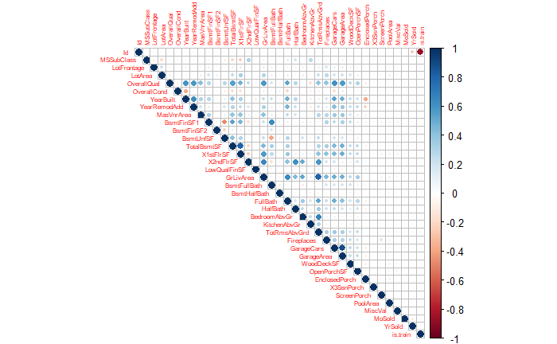

```r
CorrInp<-cor(train.num)
CorrPV<-cor.mtest(train.num)
corrplot(CorrInp, type="upper", tl.cex = 0.5)
```

```r
cor.test(train.num$TotalBsmtSF, train.num$X1stFlrSF)
```

```
    Pearson's product-moment correlation

data:  train.num$TotalBsmtSF and train.num$X1stFlrSF
t = 72.424, df = 2917, p-value < 2.2e-16
alternative hypothesis: true correlation is not equal to 0
95 percent confidence interval:
 0.7882838 0.8142369
sample estimates:
      cor
0.8016377
```

```r
cor.test(train.num$GrLivArea, train.num$TotRmsAbvGrd)
```

```
    Pearson's product-moment correlation

data:  train.num$GrLivArea and train.num$TotRmsAbvGrd
t = 74.162, df = 2917, p-value < 2.2e-16
alternative hypothesis: true correlation is not equal to 0
95 percent confidence interval:
 0.7954013 0.8205694
sample estimates:
      cor
0.8083544
```

#Investigating Normality and skew of variables #First up response

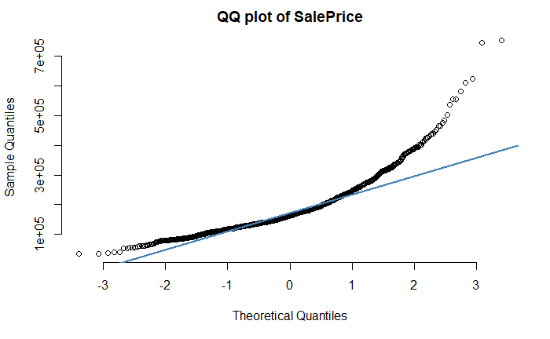

```r
qqnorm(SP, pch = 1, frame = FALSE, main = "QQ plot of SalePrice")
qqline(SP, col = "steelblue", lwd = 2)
```

#Next up most influential numerical predictors

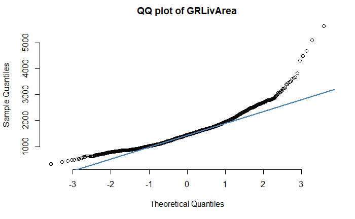

```r
qqnorm(Houses.Full$GrLivArea, pch = 1, frame = FALSE, main = "QQ plot of GRLivArea")
qqline(Houses.Full$GrLivArea, col = "steelblue", lwd = 2)
```

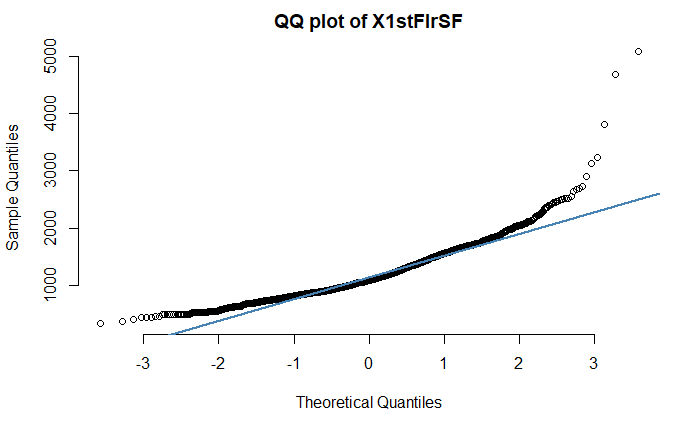

```r
qqnorm(Houses.Full$X1stFlrSF, pch = 1, frame = FALSE, main = "QQ plot of X1stFlrSF")
qqline(Houses.Full$X1stFlrSF, col = "steelblue", lwd = 2)
```

#Checking a histogram of response

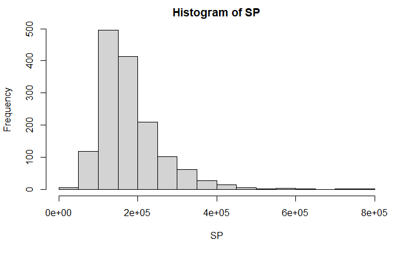

```r
hist(SP)
```

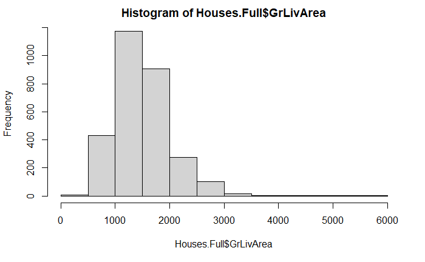

```r
hist(Houses.Full$GrLivArea)
```

#Normalizing all numeric predictors, basic log transformation

```r
colClass <- sapply(FullHouse.imp, class)
logtransform <- function(x){
    x <- log(1+x)

  x
}

numericCols <- setdiff(names(colClass[colClass == "integer" | colClass == "num"]),c("Id","is.train"))


FullHouse.imp <- FullHouse.imp %>% mutate_at(.vars=colnames(FullHouse.imp)[colClass == "integer" | colClass == "num"], funs(logtransform))
```

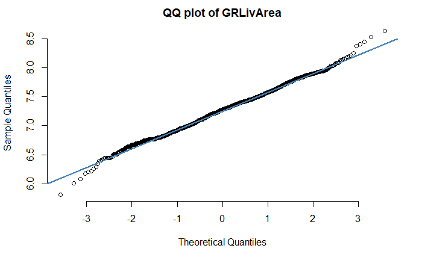

```r
qqnorm(FullHouse.imp$GrLivArea, pch = 1, frame = FALSE, main = "QQ plot of GRLivArea")
qqline(FullHouse.imp$GrLivArea, col = "steelblue", lwd = 2)
```

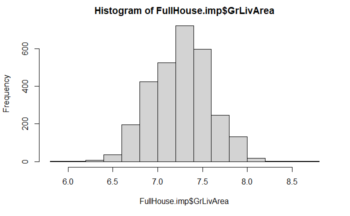

```r
hist(FullHouse.imp$GrLivArea)
```

#Log transformation of response, doesn’t really matter for random forest but I want to be able to use this code fo other models sooo

```r
LogSP<-log(SP)
```

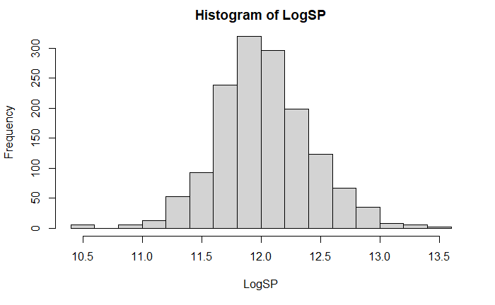

```r
hist(LogSP)
```

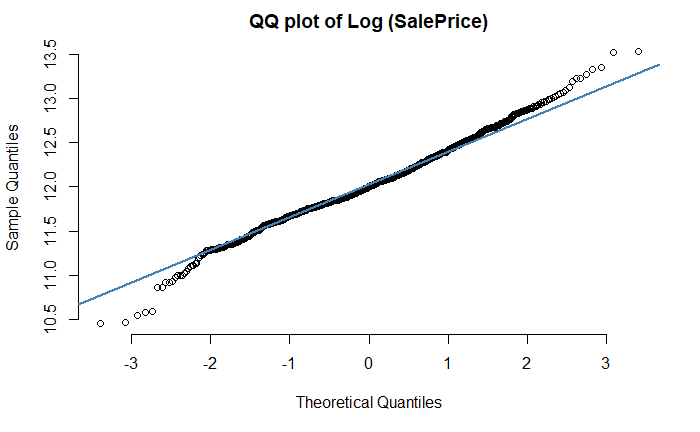

```r
qqnorm(LogSP, pch = 1, frame = FALSE, main = "QQ plot of Log (SalePrice)")
qqline(LogSP, col = "steelblue", lwd = 2)
```

#Splitting back into training and test set

```r
train <- filter(FullHouse.imp, is.train == 1) %>% select(-is.train)
test <- filter(FullHouse.imp, is.train == 0) %>% select(-is.train)
```

#Adding saleprice

```r
train2<-cbind(train, LogSP)
```

```r
colSums(is.na(train2))
```

```
           Id    MSSubClass      MSZoning   LotFrontage       LotArea        Street         Alley
            0             0             0             0             0             0             0
     LotShape   LandContour     Utilities     LotConfig     LandSlope  Neighborhood    Condition1
            0             0             0             0             0             0             0
   Condition2      BldgType    HouseStyle   OverallQual   OverallCond     YearBuilt  YearRemodAdd
            0             0             0             0             0             0             0
    RoofStyle      RoofMatl   Exterior1st   Exterior2nd    MasVnrType    MasVnrArea     ExterQual
            0             0             0             0             0             0             0
    ExterCond    Foundation      BsmtQual      BsmtCond  BsmtExposure  BsmtFinType1    BsmtFinSF1
            0             0             0             0             0             0             0
 BsmtFinType2    BsmtFinSF2     BsmtUnfSF   TotalBsmtSF       Heating     HeatingQC    CentralAir
            0             0             0             0             0             0             0
   Electrical     X1stFlrSF     X2ndFlrSF  LowQualFinSF     GrLivArea  BsmtFullBath  BsmtHalfBath
            0             0             0             0             0             0             0
     FullBath      HalfBath  BedroomAbvGr  KitchenAbvGr   KitchenQual  TotRmsAbvGrd    Functional
            0             0             0             0             0             0             0
   Fireplaces   FireplaceQu    GarageType   GarageYrBlt  GarageFinish    GarageCars    GarageArea
            0             0             0             0             0             0             0
   GarageQual    GarageCond    PavedDrive    WoodDeckSF   OpenPorchSF EnclosedPorch    X3SsnPorch
            0             0             0             0             0             0             0
  ScreenPorch      PoolArea        PoolQC         Fence   MiscFeature       MiscVal        MoSold
            0             0             0             0             0             0             0
       YrSold      SaleType SaleCondition         LogSP
            0             0             0             0
```

```r
FinalTrain<-rename(train2, SalePrice=LogSP)
```

```r
str(FinalTrain)
```

```
'data.frame':   1460 obs. of  81 variables:
 $ Id           : num  0.693 1.099 1.386 1.609 1.792 ...
 $ MSSubClass   : num  4.11 3.04 4.11 4.26 4.11 ...
 $ MSZoning     : Factor w/ 5 levels "C (all)","FV",..: 4 4 4 4 4 4 4 4 5 4 ...
 $ LotFrontage  : num  4.19 4.39 4.23 4.11 4.44 ...
 $ LotArea      : num  9.04 9.17 9.33 9.16 9.57 ...
 $ Street       : Factor w/ 2 levels "Grvl","Pave": 2 2 2 2 2 2 2 2 2 2 ...
 $ Alley        : Factor w/ 3 levels "Grvl","invalid",..: 2 2 2 2 2 2 2 2 2 2 ...
 $ LotShape     : Factor w/ 4 levels "IR1","IR2","IR3",..: 4 4 1 1 1 1 4 1 4 4 ...
 $ LandContour  : Factor w/ 4 levels "Bnk","HLS","Low",..: 4 4 4 4 4 4 4 4 4 4 ...
 $ Utilities    : Factor w/ 2 levels "AllPub","NoSeWa": 1 1 1 1 1 1 1 1 1 1 ...
 $ LotConfig    : Factor w/ 5 levels "Corner","CulDSac",..: 5 3 5 1 3 5 5 1 5 1 ...
 $ LandSlope    : Factor w/ 3 levels "Gtl","Mod","Sev": 1 1 1 1 1 1 1 1 1 1 ...
 $ Neighborhood : Factor w/ 25 levels "Blmngtn","Blueste",..: 6 25 6 7 14 12 21 17 18 4 ...
 $ Condition1   : Factor w/ 9 levels "Artery","Feedr",..: 3 2 3 3 3 3 3 5 1 1 ...
```

[output cut: 67 more lines]

Cross Validation and tuning of boosting model

```r
library(caret)
library(gbm)
library(hydroGOF)
library(Metrics)
# Using caret with the default grid to optimize tune parameters automatically
# GBM Tuning parameters:
# n.trees (# Boosting Iterations)
# interaction.depth (Max Tree Depth)
# shrinkage (Shrinkage)
# n.minobsinnode (Min. Terminal Node Size)

metric <- "RMSE"
trainControl <- trainControl(method="cv", number=7)

gbm.caret <- train(SalePrice~.-Id-GarageYrBlt
                   , data=FinalTrain
                   , distribution="gaussian"
                   , method="gbm"
                   , trControl=trainControl
                   , verbose=FALSE
                   #, tuneGrid=caretGrid
                   , metric=metric
                   , bag.fraction=0.75
                   )
```

[output not shown]

[output cut: 65 more lines]

[output not shown]

```r
print(gbm.caret)
```

```
Stochastic Gradient Boosting

1460 samples
  80 predictor

No pre-processing
Resampling: Cross-Validated (7 fold)
Summary of sample sizes: 1252, 1252, 1251, 1252, 1252, 1250, ...
Resampling results across tuning parameters:

  interaction.depth  n.trees  RMSE       Rsquared   MAE
  1                   50      0.1765400  0.8315805  0.12323814
  1                  100      0.1490743  0.8638212  0.10343859
  1                  150      0.1415514  0.8744870  0.09765394
  2                   50      0.1535661  0.8602644  0.10680301
  2                  100      0.1395175  0.8778997  0.09550798
  2                  150      0.1356820  0.8842296  0.09218433
  3                   50      0.1456420  0.8702577  0.09988311
  3                  100      0.1350518  0.8845729  0.09190620
  3                  150      0.1325573  0.8889412  0.08955807

Tuning parameter 'shrinkage' was held constant at a value of 0.1
Tuning parameter 'n.minobsinnode' was
 held constant at a value of 10
RMSE was used to select the optimal model using the smallest value.
The final values used for the model were n.trees = 150, interaction.depth = 3, shrinkage = 0.1
 and n.minobsinnode = 10.
```

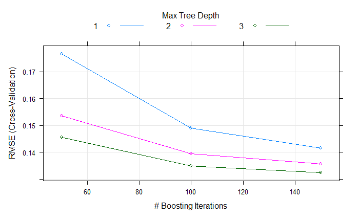

```r
plot(gbm.caret)
```

```r
boost.housing <- gbm(SalePrice~.-Id-GarageYrBlt-PoolQC-PoolArea-GarageQual-PavedDrive-MasVnrType-Alley-LotShape, data=FinalTrain, distribution="gaussian", n.trees=150, shrinkage = 0.1, interaction.depth = 3)
```

|  | var | rel.inf |
| --- | --- | --- |
| OverallQual | OverallQual | 28.83395910 |
| GrLivArea | GrLivArea | 17.84078049 |
| Neighborhood | Neighborhood | 17.25963939 |
| TotalBsmtSF | TotalBsmtSF | 5.06569829 |
| ExterQual | ExterQual | 4.02458657 |
| GarageCars | GarageCars | 2.43291047 |
| X1stFlrSF | X1stFlrSF | 2.10683283 |
| KitchenQual | KitchenQual | 2.08172083 |
| BsmtFinSF1 | BsmtFinSF1 | 1.91379804 |
| GarageType | GarageType | 1.88494872 |

[output cut: 61 more lines]

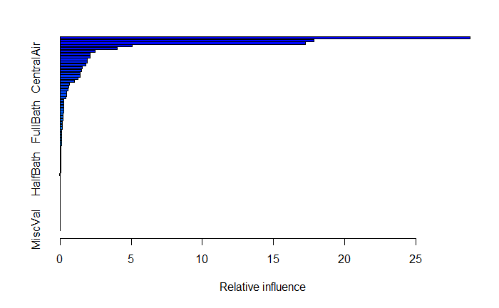

```r
summary(boost.housing)
```

```r
pred.boost<- predict(boost.housing, test)
```

```
Using 150 trees...
```

```r
summary(pred.boost)
```

```
   Min. 1st Qu.  Median    Mean 3rd Qu.    Max.
  10.63   11.77   11.96   12.01   12.24   13.18
```

#Output boosting version

#Undoing log transformation of saleprice

```r
ClosingSale<-exp(pred.boost)
```

```r
houses.solution2 = data.frame( houses.test$Id, ClosingSale)
```

```r
write.csv(file = "C:/Storage/Notes/Machine/HousingSolutions2.csv", houses.solution2, row.names = FALSE)
```

```r
set.seed(143)
```